# Risk Factor Analysis

## Outcome Variable

**Outcome Variable:** ever_stunted

## Predictor Variables

**Intervention Variable:** impfloor

**Adjustment Set:**

unadjusted

## Stratifying Variables

The analysis was stratified on these variable(s):

- agecat
- studyid
- country

## Data Summary

| agecat | studyid | country | impfloor | ever_stunted | n_cell | n |
| --- | --- | --- | --- | --- | --- | --- |
| 0-24 months (no birth st.) | ki0047075b-MAL-ED | BANGLADESH | 1 | 0 | 85 | 203 |
| 0-24 months (no birth st.) | ki0047075b-MAL-ED | BANGLADESH | 1 | 1 | 101 | 203 |
| 0-24 months (no birth st.) | ki0047075b-MAL-ED | BANGLADESH | 0 | 0 | 8 | 203 |
| 0-24 months (no birth st.) | ki0047075b-MAL-ED | BANGLADESH | 0 | 1 | 9 | 203 |
| 0-24 months (no birth st.) | ki0047075b-MAL-ED | BRAZIL | 1 | 0 | 152 | 185 |
| 0-24 months (no birth st.) | ki0047075b-MAL-ED | BRAZIL | 1 | 1 | 31 | 185 |
| 0-24 months (no birth st.) | ki0047075b-MAL-ED | BRAZIL | 0 | 0 | 2 | 185 |
| 0-24 months (no birth st.) | ki0047075b-MAL-ED | BRAZIL | 0 | 1 | 0 | 185 |
| 0-24 months (no birth st.) | ki0047075b-MAL-ED | INDIA | 1 | 0 | 85 | 197 |
| 0-24 months (no birth st.) | ki0047075b-MAL-ED | INDIA | 1 | 1 | 98 | 197 |
| 0-24 months (no birth st.) | ki0047075b-MAL-ED | INDIA | 0 | 0 | 4 | 197 |
| 0-24 months (no birth st.) | ki0047075b-MAL-ED | INDIA | 0 | 1 | 10 | 197 |
| 0-24 months (no birth st.) | ki0047075b-MAL-ED | NEPAL | 1 | 0 | 72 | 202 |
| 0-24 months (no birth st.) | ki0047075b-MAL-ED | NEPAL | 1 | 1 | 14 | 202 |
| 0-24 months (no birth st.) | ki0047075b-MAL-ED | NEPAL | 0 | 0 | 78 | 202 |
| 0-24 months (no birth st.) | ki0047075b-MAL-ED | NEPAL | 0 | 1 | 38 | 202 |
| 0-24 months (no birth st.) | ki0047075b-MAL-ED | PERU | 1 | 0 | 21 | 238 |
| 0-24 months (no birth st.) | ki0047075b-MAL-ED | PERU | 1 | 1 | 27 | 238 |
| 0-24 months (no birth st.) | ki0047075b-MAL-ED | PERU | 0 | 0 | 70 | 238 |
| 0-24 months (no birth st.) | ki0047075b-MAL-ED | PERU | 0 | 1 | 120 | 238 |
| 0-24 months (no birth st.) | ki0047075b-MAL-ED | SOUTH AFRICA | 1 | 0 | 91 | 229 |
| 0-24 months (no birth st.) | ki0047075b-MAL-ED | SOUTH AFRICA | 1 | 1 | 118 | 229 |
| 0-24 months (no birth st.) | ki0047075b-MAL-ED | SOUTH AFRICA | 0 | 0 | 7 | 229 |
| 0-24 months (no birth st.) | ki0047075b-MAL-ED | SOUTH AFRICA | 0 | 1 | 13 | 229 |
| 0-24 months (no birth st.) | ki0047075b-MAL-ED | TANZANIA, UNITED REPUBLIC OF | 1 | 0 | 3 | 209 |
| 0-24 months (no birth st.) | ki0047075b-MAL-ED | TANZANIA, UNITED REPUBLIC OF | 1 | 1 | 8 | 209 |
| 0-24 months (no birth st.) | ki0047075b-MAL-ED | TANZANIA, UNITED REPUBLIC OF | 0 | 0 | 31 | 209 |
| 0-24 months (no birth st.) | ki0047075b-MAL-ED | TANZANIA, UNITED REPUBLIC OF | 0 | 1 | 167 | 209 |
| 0-24 months (no birth st.) | ki1000108-CMC-V-BCS-2002 | INDIA | 1 | 0 | 21 | 198 |
| 0-24 months (no birth st.) | ki1000108-CMC-V-BCS-2002 | INDIA | 1 | 1 | 177 | 198 |

[output cut: 162 more lines]

The following strata were considered:

- agecat: 0-24 months (no birth st.), studyid: ki0047075b-MAL-ED, country: BANGLADESH
- agecat: 0-24 months (no birth st.), studyid: ki0047075b-MAL-ED, country: BRAZIL
- agecat: 0-24 months (no birth st.), studyid: ki0047075b-MAL-ED, country: INDIA
- agecat: 0-24 months (no birth st.), studyid: ki0047075b-MAL-ED, country: NEPAL
- agecat: 0-24 months (no birth st.), studyid: ki0047075b-MAL-ED, country: PERU
- agecat: 0-24 months (no birth st.), studyid: ki0047075b-MAL-ED, country: SOUTH AFRICA
- agecat: 0-24 months (no birth st.), studyid: ki0047075b-MAL-ED, country: TANZANIA, UNITED REPUBLIC OF
- agecat: 0-24 months (no birth st.), studyid: ki1000108-CMC-V-BCS-2002, country: INDIA
- agecat: 0-24 months (no birth st.), studyid: ki1000108-IRC, country: INDIA
- agecat: 0-24 months (no birth st.), studyid: ki1017093-NIH-Birth, country: BANGLADESH
- agecat: 0-24 months (no birth st.), studyid: ki1017093b-PROVIDE, country: BANGLADESH
- agecat: 0-24 months (no birth st.), studyid: ki1017093c-NIH-Crypto, country: BANGLADESH
- agecat: 0-24 months (no birth st.), studyid: ki1113344-GMS-Nepal, country: NEPAL
- agecat: 0-24 months (no birth st.), studyid: ki1114097-CONTENT, country: PERU
- agecat: 0-24 months (no birth st.), studyid: kiGH5241-JiVitA-3, country: BANGLADESH
- agecat: 0-24 months (no birth st.), studyid: kiGH5241-JiVitA-4, country: BANGLADESH
- agecat: 0-6 months (no birth st.), studyid: ki0047075b-MAL-ED, country: BANGLADESH
- agecat: 0-6 months (no birth st.), studyid: ki0047075b-MAL-ED, country: BRAZIL
- agecat: 0-6 months (no birth st.), studyid: ki0047075b-MAL-ED, country: INDIA
- agecat: 0-6 months (no birth st.), studyid: ki0047075b-MAL-ED, country: NEPAL
- agecat: 0-6 months (no birth st.), studyid: ki0047075b-MAL-ED, country: PERU
- agecat: 0-6 months (no birth st.), studyid: ki0047075b-MAL-ED, country: SOUTH AFRICA
- agecat: 0-6 months (no birth st.), studyid: ki0047075b-MAL-ED, country: TANZANIA, UNITED REPUBLIC OF
- agecat: 0-6 months (no birth st.), studyid: ki1000108-CMC-V-BCS-2002, country: INDIA
- agecat: 0-6 months (no birth st.), studyid: ki1000108-IRC, country: INDIA
- agecat: 0-6 months (no birth st.), studyid: ki1017093-NIH-Birth, country: BANGLADESH
- agecat: 0-6 months (no birth st.), studyid: ki1017093b-PROVIDE, country: BANGLADESH
- agecat: 0-6 months (no birth st.), studyid: ki1017093c-NIH-Crypto, country: BANGLADESH
- agecat: 0-6 months (no birth st.), studyid: ki1113344-GMS-Nepal, country: NEPAL
- agecat: 0-6 months (no birth st.), studyid: ki1114097-CONTENT, country: PERU
- agecat: 0-6 months (no birth st.), studyid: kiGH5241-JiVitA-3, country: BANGLADESH
- agecat: 0-6 months (no birth st.), studyid: kiGH5241-JiVitA-4, country: BANGLADESH
- agecat: 6-24 months, studyid: ki0047075b-MAL-ED, country: BANGLADESH
- agecat: 6-24 months, studyid: ki0047075b-MAL-ED, country: BRAZIL
- agecat: 6-24 months, studyid: ki0047075b-MAL-ED, country: INDIA
- agecat: 6-24 months, studyid: ki0047075b-MAL-ED, country: NEPAL
- agecat: 6-24 months, studyid: ki0047075b-MAL-ED, country: PERU
- agecat: 6-24 months, studyid: ki0047075b-MAL-ED, country: SOUTH AFRICA
- agecat: 6-24 months, studyid: ki0047075b-MAL-ED, country: TANZANIA, UNITED REPUBLIC OF
- agecat: 6-24 months, studyid: ki1000108-CMC-V-BCS-2002, country: INDIA
- agecat: 6-24 months, studyid: ki1000108-IRC, country: INDIA
- agecat: 6-24 months, studyid: ki1017093-NIH-Birth, country: BANGLADESH
- agecat: 6-24 months, studyid: ki1017093b-PROVIDE, country: BANGLADESH
- agecat: 6-24 months, studyid: ki1017093c-NIH-Crypto, country: BANGLADESH
- agecat: 6-24 months, studyid: ki1113344-GMS-Nepal, country: NEPAL
- agecat: 6-24 months, studyid: ki1114097-CONTENT, country: PERU
- agecat: 6-24 months, studyid: kiGH5241-JiVitA-3, country: BANGLADESH
- agecat: 6-24 months, studyid: kiGH5241-JiVitA-4, country: BANGLADESH

### Dropped Strata

Some strata were dropped due to rare outcomes:

- agecat: 0-24 months (no birth st.), studyid: ki0047075b-MAL-ED, country: BRAZIL
- agecat: 0-24 months (no birth st.), studyid: ki0047075b-MAL-ED, country: INDIA
- agecat: 0-24 months (no birth st.), studyid: ki0047075b-MAL-ED, country: TANZANIA, UNITED REPUBLIC OF
- agecat: 0-24 months (no birth st.), studyid: ki1000108-CMC-V-BCS-2002, country: INDIA
- agecat: 0-24 months (no birth st.), studyid: ki1000108-IRC, country: INDIA
- agecat: 0-24 months (no birth st.), studyid: ki1114097-CONTENT, country: PERU
- agecat: 0-6 months (no birth st.), studyid: ki0047075b-MAL-ED, country: BANGLADESH
- agecat: 0-6 months (no birth st.), studyid: ki0047075b-MAL-ED, country: BRAZIL
- agecat: 0-6 months (no birth st.), studyid: ki0047075b-MAL-ED, country: INDIA
- agecat: 0-6 months (no birth st.), studyid: ki0047075b-MAL-ED, country: NEPAL
- agecat: 0-6 months (no birth st.), studyid: ki0047075b-MAL-ED, country: TANZANIA, UNITED REPUBLIC OF
- agecat: 0-6 months (no birth st.), studyid: ki1000108-CMC-V-BCS-2002, country: INDIA
- agecat: 0-6 months (no birth st.), studyid: ki1000108-IRC, country: INDIA
- agecat: 0-6 months (no birth st.), studyid: ki1114097-CONTENT, country: PERU
- agecat: 6-24 months, studyid: ki0047075b-MAL-ED, country: BRAZIL
- agecat: 6-24 months, studyid: ki0047075b-MAL-ED, country: INDIA
- agecat: 6-24 months, studyid: ki0047075b-MAL-ED, country: TANZANIA, UNITED REPUBLIC OF
- agecat: 6-24 months, studyid: ki1000108-CMC-V-BCS-2002, country: INDIA
- agecat: 6-24 months, studyid: ki1000108-IRC, country: INDIA
- agecat: 6-24 months, studyid: ki1114097-CONTENT, country: PERU

## Methods Detail

We’re interested in the causal parameters $E[Y_a]$ for all values of $a \in \mathcal{A}$. These parameters represent the mean outcome if, possibly contrary to fact, we intervened to set all units to have $A=a$. Under the randomization and positivity assumptions, these are identified by the statistical parameters $\psi_a=E_W[E_{Y|A,W}(Y|A=a,W)]$. In addition, we’re interested in the mean of $Y$, $E[Y]$ under no intervention (the observed mean). We will estimate these parameters by using SuperLearner to fit the relevant likelihood factors – $E_{Y|A,W}(Y|A=a,W)$ and $p(A=a|W)$, and then updating our likelihood fit using a joint TMLE.

For unadjusted analyses ($W=\{\}$), initial likelihoods were estimated using Lrnr_glm to estimate the simple $E(Y|A)$ and Lrnr_mean to estimate $p(A)$. For adjusted analyses, a small library containing Lrnr_glmnet, Lrnr_xgboost, and Lrnr_mean was used.

Having estimated these parameters, we will then use the delta method to estimate relative risks and attributable risks relative to a prespecified baseline level of $A$.

# Results Detail

## Results Plots

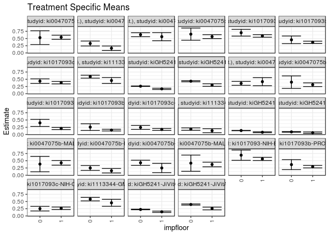

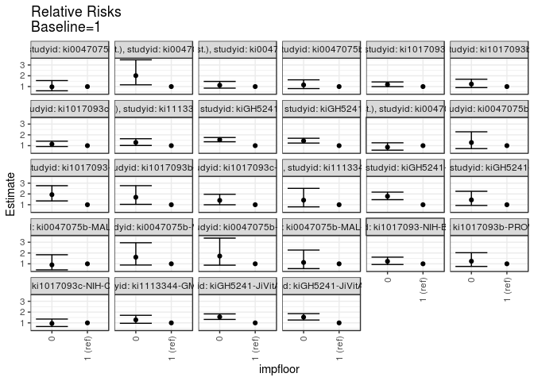

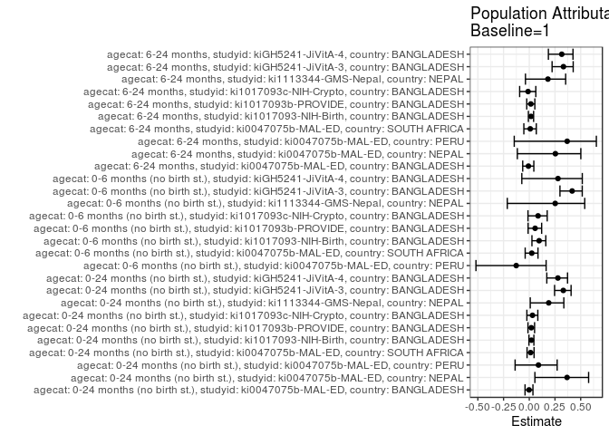

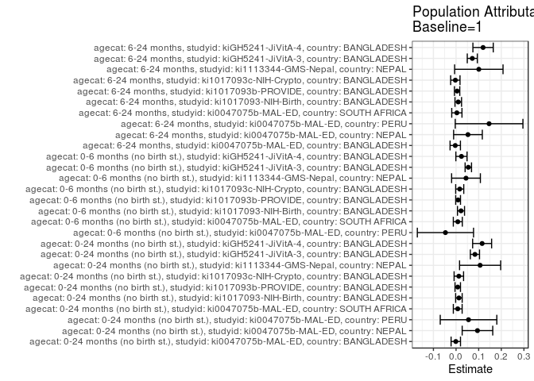

## Results Table

### Parameter: TSM

| agecat | studyid | country | intervention_level | baseline_level | estimate | ci_lower | ci_upper |
| --- | --- | --- | --- | --- | --- | --- | --- |
| 0-24 months (no birth st.) | ki0047075b-MAL-ED | BANGLADESH | 1 | NA | 0.5430108 | 0.4712444 | 0.6147772 |
| 0-24 months (no birth st.) | ki0047075b-MAL-ED | BANGLADESH | 0 | NA | 0.5294118 | 0.2915562 | 0.7672673 |
| 0-24 months (no birth st.) | ki0047075b-MAL-ED | NEPAL | 1 | NA | 0.1627907 | 0.0845724 | 0.2410090 |
| 0-24 months (no birth st.) | ki0047075b-MAL-ED | NEPAL | 0 | NA | 0.3275862 | 0.2419657 | 0.4132067 |
| 0-24 months (no birth st.) | ki0047075b-MAL-ED | PERU | 1 | NA | 0.5625000 | 0.4218654 | 0.7031346 |
| 0-24 months (no birth st.) | ki0047075b-MAL-ED | PERU | 0 | NA | 0.6315789 | 0.5628449 | 0.7003130 |
| 0-24 months (no birth st.) | ki0047075b-MAL-ED | SOUTH AFRICA | 1 | NA | 0.5645933 | 0.4972273 | 0.6319593 |
| 0-24 months (no birth st.) | ki0047075b-MAL-ED | SOUTH AFRICA | 0 | NA | 0.6500000 | 0.4405048 | 0.8594952 |
| 0-24 months (no birth st.) | ki1017093-NIH-Birth | BANGLADESH | 1 | NA | 0.5884861 | 0.5439069 | 0.6330654 |
| 0-24 months (no birth st.) | ki1017093-NIH-Birth | BANGLADESH | 0 | NA | 0.7000000 | 0.5839372 | 0.8160628 |
| 0-24 months (no birth st.) | ki1017093b-PROVIDE | BANGLADESH | 1 | NA | 0.3685121 | 0.3291539 | 0.4078704 |
| 0-24 months (no birth st.) | ki1017093b-PROVIDE | BANGLADESH | 0 | NA | 0.4545455 | 0.3228478 | 0.5862431 |
| 0-24 months (no birth st.) | ki1017093c-NIH-Crypto | BANGLADESH | 1 | NA | 0.3812375 | 0.3386755 | 0.4237995 |
| 0-24 months (no birth st.) | ki1017093c-NIH-Crypto | BANGLADESH | 0 | NA | 0.4342105 | 0.3553542 | 0.5130669 |
| 0-24 months (no birth st.) | ki1113344-GMS-Nepal | NEPAL | 1 | NA | 0.4565217 | 0.3546260 | 0.5584174 |
| 0-24 months (no birth st.) | ki1113344-GMS-Nepal | NEPAL | 0 | NA | 0.5900277 | 0.5392366 | 0.6408188 |
| 0-24 months (no birth st.) | kiGH5241-JiVitA-3 | BANGLADESH | 1 | NA | 0.1686820 | 0.1477051 | 0.1896589 |
| 0-24 months (no birth st.) | kiGH5241-JiVitA-3 | BANGLADESH | 0 | NA | 0.2604523 | 0.2523784 | 0.2685262 |
| 0-24 months (no birth st.) | kiGH5241-JiVitA-4 | BANGLADESH | 1 | NA | 0.2990291 | 0.2552764 | 0.3427819 |
| 0-24 months (no birth st.) | kiGH5241-JiVitA-4 | BANGLADESH | 0 | NA | 0.4319738 | 0.4121518 | 0.4517958 |
| 0-6 months (no birth st.) | ki0047075b-MAL-ED | PERU | 1 | NA | 0.4166667 | 0.2769029 | 0.5564304 |
| 0-6 months (no birth st.) | ki0047075b-MAL-ED | PERU | 0 | NA | 0.3578947 | 0.2895876 | 0.4262019 |
| 0-6 months (no birth st.) | ki0047075b-MAL-ED | SOUTH AFRICA | 1 | NA | 0.3110048 | 0.2481097 | 0.3738999 |
| 0-6 months (no birth st.) | ki0047075b-MAL-ED | SOUTH AFRICA | 0 | NA | 0.4000000 | 0.1848264 | 0.6151736 |
| 0-6 months (no birth st.) | ki1017093-NIH-Birth | BANGLADESH | 1 | NA | 0.2068230 | 0.1701322 | 0.2435138 |
| 0-6 months (no birth st.) | ki1017093-NIH-Birth | BANGLADESH | 0 | NA | 0.4000000 | 0.2759237 | 0.5240763 |
| 0-6 months (no birth st.) | ki1017093b-PROVIDE | BANGLADESH | 1 | NA | 0.1505190 | 0.1213448 | 0.1796933 |
| 0-6 months (no birth st.) | ki1017093b-PROVIDE | BANGLADESH | 0 | NA | 0.2545455 | 0.1393320 | 0.3697589 |
| 0-6 months (no birth st.) | ki1017093c-NIH-Crypto | BANGLADESH | 1 | NA | 0.1736527 | 0.1404568 | 0.2068486 |
| 0-6 months (no birth st.) | ki1017093c-NIH-Crypto | BANGLADESH | 0 | NA | 0.2434211 | 0.1751455 | 0.3116966 |
| 0-6 months (no birth st.) | ki1113344-GMS-Nepal | NEPAL | 1 | NA | 0.1304348 | 0.0615407 | 0.1993289 |
| 0-6 months (no birth st.) | ki1113344-GMS-Nepal | NEPAL | 0 | NA | 0.1855956 | 0.1454462 | 0.2257449 |
| 0-6 months (no birth st.) | kiGH5241-JiVitA-3 | BANGLADESH | 1 | NA | 0.0759417 | 0.0614372 | 0.0904461 |
| 0-6 months (no birth st.) | kiGH5241-JiVitA-3 | BANGLADESH | 0 | NA | 0.1355576 | 0.1296904 | 0.1414247 |
| 0-6 months (no birth st.) | kiGH5241-JiVitA-4 | BANGLADESH | 1 | NA | 0.0616016 | 0.0359026 | 0.0873007 |
| 0-6 months (no birth st.) | kiGH5241-JiVitA-4 | BANGLADESH | 0 | NA | 0.0891277 | 0.0766684 | 0.1015870 |
| 6-24 months | ki0047075b-MAL-ED | BANGLADESH | 1 | NA | 0.4275862 | 0.3468051 | 0.5083673 |
| 6-24 months | ki0047075b-MAL-ED | BANGLADESH | 0 | NA | 0.3846154 | 0.1193126 | 0.6499181 |
| 6-24 months | ki0047075b-MAL-ED | NEPAL | 1 | NA | 0.1547619 | 0.0772108 | 0.2323130 |
| 6-24 months | ki0047075b-MAL-ED | NEPAL | 0 | NA | 0.2500000 | 0.1665569 | 0.3334431 |
| 6-24 months | ki0047075b-MAL-ED | PERU | 1 | NA | 0.2500000 | 0.0890719 | 0.4109281 |
| 6-24 months | ki0047075b-MAL-ED | PERU | 0 | NA | 0.4297521 | 0.3412490 | 0.5182552 |
| 6-24 months | ki0047075b-MAL-ED | SOUTH AFRICA | 1 | NA | 0.3706294 | 0.2912132 | 0.4500455 |
| 6-24 months | ki0047075b-MAL-ED | SOUTH AFRICA | 0 | NA | 0.4166667 | 0.1368228 | 0.6965105 |
| 6-24 months | ki1017093-NIH-Birth | BANGLADESH | 1 | NA | 0.5628931 | 0.5082955 | 0.6174907 |
| 6-24 months | ki1017093-NIH-Birth | BANGLADESH | 0 | NA | 0.6923077 | 0.5146429 | 0.8699725 |
| 6-24 months | ki1017093b-PROVIDE | BANGLADESH | 1 | NA | 0.2957746 | 0.2523880 | 0.3391613 |
| 6-24 months | ki1017093b-PROVIDE | BANGLADESH | 0 | NA | 0.3666667 | 0.1940367 | 0.5392966 |
| 6-24 months | ki1017093c-NIH-Crypto | BANGLADESH | 1 | NA | 0.2659847 | 0.2221447 | 0.3098246 |
| 6-24 months | ki1017093c-NIH-Crypto | BANGLADESH | 0 | NA | 0.2521739 | 0.1727266 | 0.3316212 |
| 6-24 months | ki1113344-GMS-Nepal | NEPAL | 1 | NA | 0.4545455 | 0.3342276 | 0.5748633 |
| 6-24 months | ki1113344-GMS-Nepal | NEPAL | 0 | NA | 0.5816733 | 0.5205517 | 0.6427949 |
| 6-24 months | kiGH5241-JiVitA-3 | BANGLADESH | 1 | NA | 0.1443015 | 0.1211086 | 0.1674944 |
| 6-24 months | kiGH5241-JiVitA-3 | BANGLADESH | 0 | NA | 0.2244246 | 0.2145350 | 0.2343142 |
| 6-24 months | kiGH5241-JiVitA-4 | BANGLADESH | 1 | NA | 0.2587992 | 0.2111584 | 0.3064400 |
| 6-24 months | kiGH5241-JiVitA-4 | BANGLADESH | 0 | NA | 0.3965190 | 0.3764032 | 0.4166348 |

### Parameter: E(Y)

| agecat | studyid | country | intervention_level | baseline_level | estimate | ci_lower | ci_upper |
| --- | --- | --- | --- | --- | --- | --- | --- |
| 0-24 months (no birth st.) | ki0047075b-MAL-ED | BANGLADESH | NA | NA | 0.5418719 | 0.4731628 | 0.6105810 |
| 0-24 months (no birth st.) | ki0047075b-MAL-ED | NEPAL | NA | NA | 0.2574257 | 0.1969827 | 0.3178687 |
| 0-24 months (no birth st.) | ki0047075b-MAL-ED | PERU | NA | NA | 0.6176471 | 0.5557776 | 0.6795165 |
| 0-24 months (no birth st.) | ki0047075b-MAL-ED | SOUTH AFRICA | NA | NA | 0.5720524 | 0.5078289 | 0.6362759 |
| 0-24 months (no birth st.) | ki1017093-NIH-Birth | BANGLADESH | NA | NA | 0.6011342 | 0.5593675 | 0.6429009 |
| 0-24 months (no birth st.) | ki1017093b-PROVIDE | BANGLADESH | NA | NA | 0.3759874 | 0.3382238 | 0.4137509 |
| 0-24 months (no birth st.) | ki1017093c-NIH-Crypto | BANGLADESH | NA | NA | 0.3935681 | 0.3560687 | 0.4310676 |
| 0-24 months (no birth st.) | ki1113344-GMS-Nepal | NEPAL | NA | NA | 0.5629139 | 0.5171858 | 0.6086420 |
| 0-24 months (no birth st.) | kiGH5241-JiVitA-3 | BANGLADESH | NA | NA | 0.2521692 | 0.2444469 | 0.2598915 |
| 0-24 months (no birth st.) | kiGH5241-JiVitA-4 | BANGLADESH | NA | NA | 0.4143005 | 0.3961166 | 0.4324844 |
| 0-6 months (no birth st.) | ki0047075b-MAL-ED | PERU | NA | NA | 0.3697479 | 0.3082891 | 0.4312067 |
| 0-6 months (no birth st.) | ki0047075b-MAL-ED | SOUTH AFRICA | NA | NA | 0.3187773 | 0.2582893 | 0.3792652 |
| 0-6 months (no birth st.) | ki1017093-NIH-Birth | BANGLADESH | NA | NA | 0.2287335 | 0.1929075 | 0.2645595 |
| 0-6 months (no birth st.) | ki1017093b-PROVIDE | BANGLADESH | NA | NA | 0.1595577 | 0.1310079 | 0.1881074 |
| 0-6 months (no birth st.) | ki1017093c-NIH-Crypto | BANGLADESH | NA | NA | 0.1898928 | 0.1597870 | 0.2199986 |
| 0-6 months (no birth st.) | ki1113344-GMS-Nepal | NEPAL | NA | NA | 0.1743929 | 0.1394121 | 0.2093738 |
| 0-6 months (no birth st.) | kiGH5241-JiVitA-3 | BANGLADESH | NA | NA | 0.1301898 | 0.1246228 | 0.1357568 |
| 0-6 months (no birth st.) | kiGH5241-JiVitA-4 | BANGLADESH | NA | NA | 0.0854560 | 0.0740923 | 0.0968198 |
| 6-24 months | ki0047075b-MAL-ED | BANGLADESH | NA | NA | 0.4240506 | 0.3467471 | 0.5013542 |
| 6-24 months | ki0047075b-MAL-ED | NEPAL | NA | NA | 0.2074468 | 0.1493309 | 0.2655627 |
| 6-24 months | ki0047075b-MAL-ED | PERU | NA | NA | 0.3959732 | 0.3171819 | 0.4747644 |
| 6-24 months | ki0047075b-MAL-ED | SOUTH AFRICA | NA | NA | 0.3741935 | 0.2977649 | 0.4506221 |
| 6-24 months | ki1017093-NIH-Birth | BANGLADESH | NA | NA | 0.5726744 | 0.5203223 | 0.6250266 |
| 6-24 months | ki1017093b-PROVIDE | BANGLADESH | NA | NA | 0.3004386 | 0.2583143 | 0.3425629 |
| 6-24 months | ki1017093c-NIH-Crypto | BANGLADESH | NA | NA | 0.2628458 | 0.2244546 | 0.3012371 |
| 6-24 months | ki1113344-GMS-Nepal | NEPAL | NA | NA | 0.5552050 | 0.5004138 | 0.6099963 |
| 6-24 months | kiGH5241-JiVitA-3 | BANGLADESH | NA | NA | 0.2161001 | 0.2067207 | 0.2254795 |
| 6-24 months | kiGH5241-JiVitA-4 | BANGLADESH | NA | NA | 0.3782597 | 0.3596753 | 0.3968440 |

### Parameter: RR

| agecat | studyid | country | intervention_level | baseline_level | estimate | ci_lower | ci_upper |
| --- | --- | --- | --- | --- | --- | --- | --- |
| 0-24 months (no birth st.) | ki0047075b-MAL-ED | BANGLADESH | 1 | 1 | 1.0000000 | 1.0000000 | 1.000000 |
| 0-24 months (no birth st.) | ki0047075b-MAL-ED | BANGLADESH | 0 | 1 | 0.9749563 | 0.6103754 | 1.557304 |
| 0-24 months (no birth st.) | ki0047075b-MAL-ED | NEPAL | 1 | 1 | 1.0000000 | 1.0000000 | 1.000000 |
| 0-24 months (no birth st.) | ki0047075b-MAL-ED | NEPAL | 0 | 1 | 2.0123153 | 1.1645263 | 3.477305 |
| 0-24 months (no birth st.) | ki0047075b-MAL-ED | PERU | 1 | 1 | 1.0000000 | 1.0000000 | 1.000000 |
| 0-24 months (no birth st.) | ki0047075b-MAL-ED | PERU | 0 | 1 | 1.1228070 | 0.8548372 | 1.474779 |
| 0-24 months (no birth st.) | ki0047075b-MAL-ED | SOUTH AFRICA | 1 | 1 | 1.0000000 | 1.0000000 | 1.000000 |
| 0-24 months (no birth st.) | ki0047075b-MAL-ED | SOUTH AFRICA | 0 | 1 | 1.1512712 | 0.8164327 | 1.623435 |
| 0-24 months (no birth st.) | ki1017093-NIH-Birth | BANGLADESH | 1 | 1 | 1.0000000 | 1.0000000 | 1.000000 |
| 0-24 months (no birth st.) | ki1017093-NIH-Birth | BANGLADESH | 0 | 1 | 1.1894928 | 0.9912759 | 1.427345 |
| 0-24 months (no birth st.) | ki1017093b-PROVIDE | BANGLADESH | 1 | 1 | 1.0000000 | 1.0000000 | 1.000000 |
| 0-24 months (no birth st.) | ki1017093b-PROVIDE | BANGLADESH | 0 | 1 | 1.2334614 | 0.9057710 | 1.679704 |
| 0-24 months (no birth st.) | ki1017093c-NIH-Crypto | BANGLADESH | 1 | 1 | 1.0000000 | 1.0000000 | 1.000000 |
| 0-24 months (no birth st.) | ki1017093c-NIH-Crypto | BANGLADESH | 0 | 1 | 1.1389501 | 0.9202843 | 1.409572 |
| 0-24 months (no birth st.) | ki1113344-GMS-Nepal | NEPAL | 1 | 1 | 1.0000000 | 1.0000000 | 1.000000 |
| 0-24 months (no birth st.) | ki1113344-GMS-Nepal | NEPAL | 0 | 1 | 1.2924416 | 1.0174590 | 1.641742 |
| 0-24 months (no birth st.) | kiGH5241-JiVitA-3 | BANGLADESH | 1 | 1 | 1.0000000 | 1.0000000 | 1.000000 |
| 0-24 months (no birth st.) | kiGH5241-JiVitA-3 | BANGLADESH | 0 | 1 | 1.5440433 | 1.3598904 | 1.753134 |
| 0-24 months (no birth st.) | kiGH5241-JiVitA-4 | BANGLADESH | 1 | 1 | 1.0000000 | 1.0000000 | 1.000000 |
| 0-24 months (no birth st.) | kiGH5241-JiVitA-4 | BANGLADESH | 0 | 1 | 1.4445877 | 1.2386121 | 1.684816 |
| 0-6 months (no birth st.) | ki0047075b-MAL-ED | PERU | 1 | 1 | 1.0000000 | 1.0000000 | 1.000000 |
| 0-6 months (no birth st.) | ki0047075b-MAL-ED | PERU | 0 | 1 | 0.8589474 | 0.5839278 | 1.263496 |
| 0-6 months (no birth st.) | ki0047075b-MAL-ED | SOUTH AFRICA | 1 | 1 | 1.0000000 | 1.0000000 | 1.000000 |
| 0-6 months (no birth st.) | ki0047075b-MAL-ED | SOUTH AFRICA | 0 | 1 | 1.2861538 | 0.7239480 | 2.284959 |
| 0-6 months (no birth st.) | ki1017093-NIH-Birth | BANGLADESH | 1 | 1 | 1.0000000 | 1.0000000 | 1.000000 |
| 0-6 months (no birth st.) | ki1017093-NIH-Birth | BANGLADESH | 0 | 1 | 1.9340206 | 1.3529183 | 2.764717 |
| 0-6 months (no birth st.) | ki1017093b-PROVIDE | BANGLADESH | 1 | 1 | 1.0000000 | 1.0000000 | 1.000000 |
| 0-6 months (no birth st.) | ki1017093b-PROVIDE | BANGLADESH | 0 | 1 | 1.6911181 | 1.0335621 | 2.767014 |
| 0-6 months (no birth st.) | ki1017093c-NIH-Crypto | BANGLADESH | 1 | 1 | 1.0000000 | 1.0000000 | 1.000000 |
| 0-6 months (no birth st.) | ki1017093c-NIH-Crypto | BANGLADESH | 0 | 1 | 1.4017695 | 0.9983049 | 1.968294 |
| 0-6 months (no birth st.) | ki1113344-GMS-Nepal | NEPAL | 1 | 1 | 1.0000000 | 1.0000000 | 1.000000 |
| 0-6 months (no birth st.) | ki1113344-GMS-Nepal | NEPAL | 0 | 1 | 1.4228994 | 0.8040654 | 2.518007 |
| 0-6 months (no birth st.) | kiGH5241-JiVitA-3 | BANGLADESH | 1 | 1 | 1.0000000 | 1.0000000 | 1.000000 |
| 0-6 months (no birth st.) | kiGH5241-JiVitA-3 | BANGLADESH | 0 | 1 | 1.7850219 | 1.4693297 | 2.168542 |
| 0-6 months (no birth st.) | kiGH5241-JiVitA-4 | BANGLADESH | 1 | 1 | 1.0000000 | 1.0000000 | 1.000000 |
| 0-6 months (no birth st.) | kiGH5241-JiVitA-4 | BANGLADESH | 0 | 1 | 1.4468394 | 0.9324345 | 2.245031 |
| 6-24 months | ki0047075b-MAL-ED | BANGLADESH | 1 | 1 | 1.0000000 | 1.0000000 | 1.000000 |
| 6-24 months | ki0047075b-MAL-ED | BANGLADESH | 0 | 1 | 0.8995037 | 0.4399460 | 1.839105 |
| 6-24 months | ki0047075b-MAL-ED | NEPAL | 1 | 1 | 1.0000000 | 1.0000000 | 1.000000 |
| 6-24 months | ki0047075b-MAL-ED | NEPAL | 0 | 1 | 1.6153846 | 0.8846966 | 2.949562 |
| 6-24 months | ki0047075b-MAL-ED | PERU | 1 | 1 | 1.0000000 | 1.0000000 | 1.000000 |
| 6-24 months | ki0047075b-MAL-ED | PERU | 0 | 1 | 1.7190083 | 0.8744979 | 3.379070 |
| 6-24 months | ki0047075b-MAL-ED | SOUTH AFRICA | 1 | 1 | 1.0000000 | 1.0000000 | 1.000000 |
| 6-24 months | ki0047075b-MAL-ED | SOUTH AFRICA | 0 | 1 | 1.1242138 | 0.5554961 | 2.275186 |
| 6-24 months | ki1017093-NIH-Birth | BANGLADESH | 1 | 1 | 1.0000000 | 1.0000000 | 1.000000 |
| 6-24 months | ki1017093-NIH-Birth | BANGLADESH | 0 | 1 | 1.2299098 | 0.9348170 | 1.618154 |
| 6-24 months | ki1017093b-PROVIDE | BANGLADESH | 1 | 1 | 1.0000000 | 1.0000000 | 1.000000 |
| 6-24 months | ki1017093b-PROVIDE | BANGLADESH | 0 | 1 | 1.2396825 | 0.7570879 | 2.029900 |
| 6-24 months | ki1017093c-NIH-Crypto | BANGLADESH | 1 | 1 | 1.0000000 | 1.0000000 | 1.000000 |
| 6-24 months | ki1017093c-NIH-Crypto | BANGLADESH | 0 | 1 | 0.9480769 | 0.6643947 | 1.352885 |
| 6-24 months | ki1113344-GMS-Nepal | NEPAL | 1 | 1 | 1.0000000 | 1.0000000 | 1.000000 |
| 6-24 months | ki1113344-GMS-Nepal | NEPAL | 0 | 1 | 1.2796813 | 0.9625374 | 1.701320 |
| 6-24 months | kiGH5241-JiVitA-3 | BANGLADESH | 1 | 1 | 1.0000000 | 1.0000000 | 1.000000 |
| 6-24 months | kiGH5241-JiVitA-3 | BANGLADESH | 0 | 1 | 1.5552479 | 1.3196401 | 1.832921 |
| 6-24 months | kiGH5241-JiVitA-4 | BANGLADESH | 1 | 1 | 1.0000000 | 1.0000000 | 1.000000 |
| 6-24 months | kiGH5241-JiVitA-4 | BANGLADESH | 0 | 1 | 1.5321494 | 1.2660522 | 1.854175 |

### Parameter: PAR

| agecat | studyid | country | intervention_level | baseline_level | estimate | ci_lower | ci_upper |
| --- | --- | --- | --- | --- | --- | --- | --- |
| 0-24 months (no birth st.) | ki0047075b-MAL-ED | BANGLADESH | 1 | NA | -0.0011388 | -0.0219512 | 0.0196735 |
| 0-24 months (no birth st.) | ki0047075b-MAL-ED | NEPAL | 1 | NA | 0.0946350 | 0.0270926 | 0.1621775 |
| 0-24 months (no birth st.) | ki0047075b-MAL-ED | PERU | 1 | NA | 0.0551471 | -0.0698657 | 0.1801598 |
| 0-24 months (no birth st.) | ki0047075b-MAL-ED | SOUTH AFRICA | 1 | NA | 0.0074591 | -0.0120133 | 0.0269315 |
| 0-24 months (no birth st.) | ki1017093-NIH-Birth | BANGLADESH | 1 | NA | 0.0126481 | -0.0017726 | 0.0270687 |
| 0-24 months (no birth st.) | ki1017093b-PROVIDE | BANGLADESH | 1 | NA | 0.0074753 | -0.0046163 | 0.0195668 |
| 0-24 months (no birth st.) | ki1017093c-NIH-Crypto | BANGLADESH | 1 | NA | 0.0123306 | -0.0085986 | 0.0332598 |
| 0-24 months (no birth st.) | ki1113344-GMS-Nepal | NEPAL | 1 | NA | 0.1063922 | 0.0155267 | 0.1972576 |
| 0-24 months (no birth st.) | kiGH5241-JiVitA-3 | BANGLADESH | 1 | NA | 0.0834872 | 0.0632179 | 0.1037565 |
| 0-24 months (no birth st.) | kiGH5241-JiVitA-4 | BANGLADESH | 1 | NA | 0.1152713 | 0.0733401 | 0.1572026 |
| 0-6 months (no birth st.) | ki0047075b-MAL-ED | PERU | 1 | NA | -0.0469188 | -0.1711438 | 0.0773063 |
| 0-6 months (no birth st.) | ki0047075b-MAL-ED | SOUTH AFRICA | 1 | NA | 0.0077725 | -0.0120761 | 0.0276211 |
| 0-6 months (no birth st.) | ki1017093-NIH-Birth | BANGLADESH | 1 | NA | 0.0219104 | 0.0063327 | 0.0374882 |
| 0-6 months (no birth st.) | ki1017093b-PROVIDE | BANGLADESH | 1 | NA | 0.0090386 | -0.0015376 | 0.0196149 |
| 0-6 months (no birth st.) | ki1017093c-NIH-Crypto | BANGLADESH | 1 | NA | 0.0162401 | -0.0015758 | 0.0340560 |
| 0-6 months (no birth st.) | ki1113344-GMS-Nepal | NEPAL | 1 | NA | 0.0439582 | -0.0196198 | 0.1075361 |
| 0-6 months (no birth st.) | kiGH5241-JiVitA-3 | BANGLADESH | 1 | NA | 0.0542481 | 0.0401038 | 0.0683925 |
| 0-6 months (no birth st.) | kiGH5241-JiVitA-4 | BANGLADESH | 1 | NA | 0.0238544 | -0.0008696 | 0.0485784 |
| 6-24 months | ki0047075b-MAL-ED | BANGLADESH | 1 | NA | -0.0035356 | -0.0264284 | 0.0193572 |
| 6-24 months | ki0047075b-MAL-ED | NEPAL | 1 | NA | 0.0526849 | -0.0106970 | 0.1160668 |
| 6-24 months | ki0047075b-MAL-ED | PERU | 1 | NA | 0.1459732 | -0.0036013 | 0.2955476 |
| 6-24 months | ki0047075b-MAL-ED | SOUTH AFRICA | 1 | NA | 0.0035642 | -0.0190404 | 0.0261687 |
| 6-24 months | ki1017093-NIH-Birth | BANGLADESH | 1 | NA | 0.0097813 | -0.0047255 | 0.0242882 |
| 6-24 months | ki1017093b-PROVIDE | BANGLADESH | 1 | NA | 0.0046639 | -0.0071573 | 0.0164852 |
| 6-24 months | ki1017093c-NIH-Crypto | BANGLADESH | 1 | NA | -0.0031388 | -0.0237678 | 0.0174902 |
| 6-24 months | ki1113344-GMS-Nepal | NEPAL | 1 | NA | 0.1006596 | -0.0063472 | 0.2076664 |
| 6-24 months | kiGH5241-JiVitA-3 | BANGLADESH | 1 | NA | 0.0717986 | 0.0496098 | 0.0939874 |
| 6-24 months | kiGH5241-JiVitA-4 | BANGLADESH | 1 | NA | 0.1194605 | 0.0744922 | 0.1644288 |

### Parameter: PAF

| agecat | studyid | country | intervention_level | baseline_level | estimate | ci_lower | ci_upper |
| --- | --- | --- | --- | --- | --- | --- | --- |
| 0-24 months (no birth st.) | ki0047075b-MAL-ED | BANGLADESH | 1 | NA | -0.0021017 | -0.0412568 | 0.0355811 |
| 0-24 months (no birth st.) | ki0047075b-MAL-ED | NEPAL | 1 | NA | 0.3676208 | 0.0546195 | 0.5769920 |
| 0-24 months (no birth st.) | ki0047075b-MAL-ED | PERU | 1 | NA | 0.0892857 | -0.1378493 | 0.2710806 |
| 0-24 months (no birth st.) | ki0047075b-MAL-ED | SOUTH AFRICA | 1 | NA | 0.0130392 | -0.0216475 | 0.0465482 |
| 0-24 months (no birth st.) | ki1017093-NIH-Birth | BANGLADESH | 1 | NA | 0.0210404 | -0.0033339 | 0.0448225 |
| 0-24 months (no birth st.) | ki1017093b-PROVIDE | BANGLADESH | 1 | NA | 0.0198817 | -0.0128227 | 0.0515300 |
| 0-24 months (no birth st.) | ki1017093c-NIH-Crypto | BANGLADESH | 1 | NA | 0.0313303 | -0.0233573 | 0.0830955 |
| 0-24 months (no birth st.) | ki1113344-GMS-Nepal | NEPAL | 1 | NA | 0.1890026 | 0.0094291 | 0.3360225 |
| 0-24 months (no birth st.) | kiGH5241-JiVitA-3 | BANGLADESH | 1 | NA | 0.3310761 | 0.2460593 | 0.4065061 |
| 0-24 months (no birth st.) | kiGH5241-JiVitA-4 | BANGLADESH | 1 | NA | 0.2782313 | 0.1703448 | 0.3720884 |
| 0-6 months (no birth st.) | ki0047075b-MAL-ED | PERU | 1 | NA | -0.1268939 | -0.5186086 | 0.1637806 |
| 0-6 months (no birth st.) | ki0047075b-MAL-ED | SOUTH AFRICA | 1 | NA | 0.0243823 | -0.0398964 | 0.0846877 |
| 0-6 months (no birth st.) | ki1017093-NIH-Birth | BANGLADESH | 1 | NA | 0.0957902 | 0.0258859 | 0.1606781 |
| 0-6 months (no birth st.) | ki1017093b-PROVIDE | BANGLADESH | 1 | NA | 0.0566481 | -0.0114856 | 0.1201923 |
| 0-6 months (no birth st.) | ki1017093c-NIH-Crypto | BANGLADESH | 1 | NA | 0.0855225 | -0.0126579 | 0.1741840 |
| 0-6 months (no birth st.) | ki1113344-GMS-Nepal | NEPAL | 1 | NA | 0.2520638 | -0.2138247 | 0.5391357 |
| 0-6 months (no birth st.) | kiGH5241-JiVitA-3 | BANGLADESH | 1 | NA | 0.4166850 | 0.2983259 | 0.5150791 |
| 0-6 months (no birth st.) | kiGH5241-JiVitA-4 | BANGLADESH | 1 | NA | 0.2791423 | -0.0725020 | 0.5154920 |
| 6-24 months | ki0047075b-MAL-ED | BANGLADESH | 1 | NA | -0.0083376 | -0.0638059 | 0.0442385 |
| 6-24 months | ki0047075b-MAL-ED | NEPAL | 1 | NA | 0.2539683 | -0.1159799 | 0.5012783 |
| 6-24 months | ki0047075b-MAL-ED | PERU | 1 | NA | 0.3686441 | -0.1462161 | 0.6522381 |
| 6-24 months | ki0047075b-MAL-ED | SOUTH AFRICA | 1 | NA | 0.0095250 | -0.0527700 | 0.0681338 |
| 6-24 months | ki1017093-NIH-Birth | BANGLADESH | 1 | NA | 0.0170801 | -0.0086615 | 0.0421648 |
| 6-24 months | ki1017093b-PROVIDE | BANGLADESH | 1 | NA | 0.0155238 | -0.0246101 | 0.0540856 |
| 6-24 months | ki1017093c-NIH-Crypto | BANGLADESH | 1 | NA | -0.0119416 | -0.0935427 | 0.0635703 |
| 6-24 months | ki1113344-GMS-Nepal | NEPAL | 1 | NA | 0.1813017 | -0.0371036 | 0.3537126 |
| 6-24 months | kiGH5241-JiVitA-3 | BANGLADESH | 1 | NA | 0.3322470 | 0.2217871 | 0.4270282 |
| 6-24 months | kiGH5241-JiVitA-4 | BANGLADESH | 1 | NA | 0.3158161 | 0.1858569 | 0.4250303 |